# Module 1: Analysis of the Haemopedia Database

Jason Cosgrove (jason.cosgrove@curie.fr)

Institut Curie, UMR168

# 1 Introduction

In this analysis we analyse the haemopedia bulk RNAseq database (1) to identify metabolic signature of lineage bias. More specifically, we perform data QC and normalisation followed by differential expression and pathway enrichment analysis.

# 2 Data QC and normalisation using the LIMMA package.

Filter the dataset and normalise using limmas voom function. The voom method transforms count data to log2-counts per million (logCPM), then estimates the mean-variance relationship in the data to compute appropriate observation-level weights.

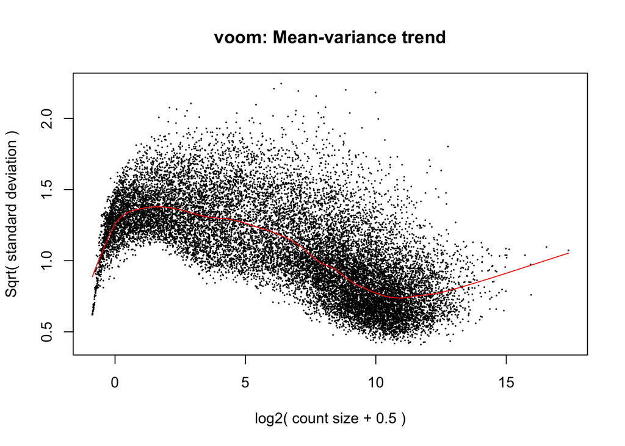

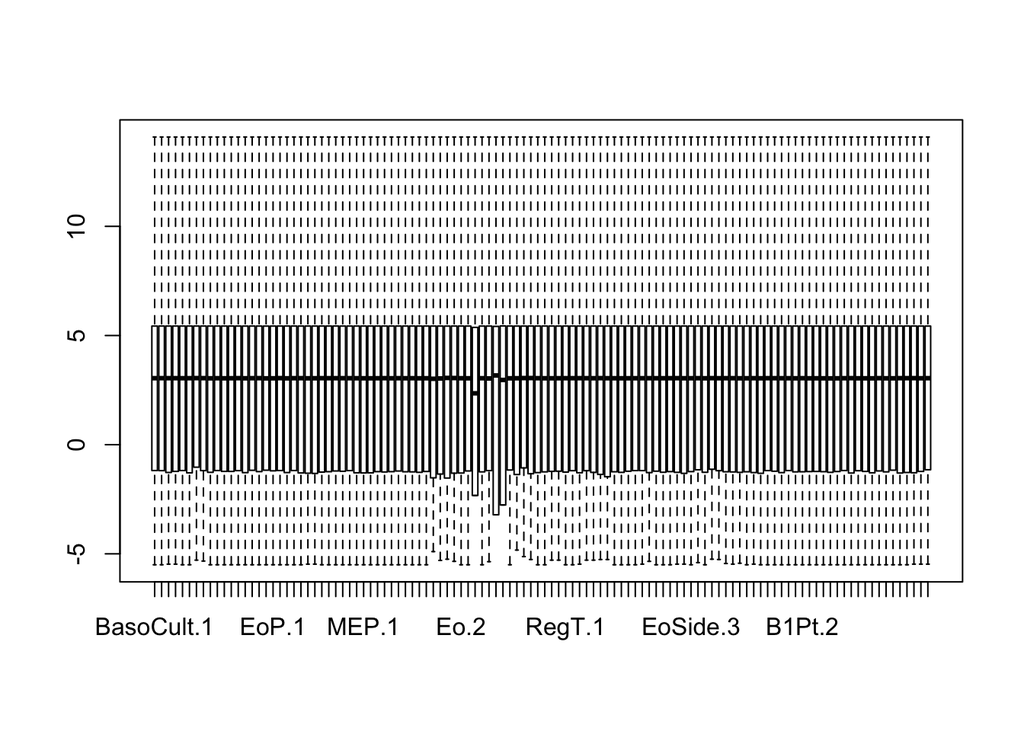

# 3 Data visualisation using the Seurat package

Convert the data into a seurat object (3) and visualise using PCA and non-linear equivalents such as UMAP

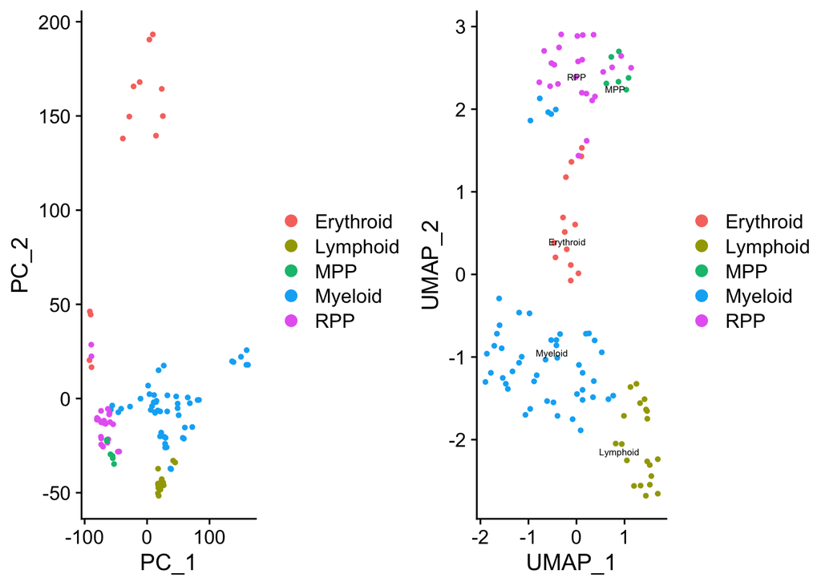

# 4 Mitochondrial genes

As we are interested in metabolism it is interesting to know how many of our genes encode for proteins that localise to the mitochondria using the mitocarta v2 database (4).

```r
mitocarta.genes <- read.csv("genesets/mitochondrial_assoc_genes.csv",header=F)

mito.genes <- intersect(rownames(haem.seurat),mitocarta.genes$V1)
haem.seurat <- AddModuleScore(haem.seurat, features = list(mito.genes),name = "mito")
VlnPlot(haem.seurat, features = "mito1",group.by = "lineage")

mito <- haem.seurat@meta.data$mito1
names(mito) <- colnames(haem.seurat)

boxplot(mito[c("STHSC.1","STHSC.2")],mito[c("MPP.1","MPP.2")]  ,mito[c("LSK.1","LSK.2")]  ,  mito[c("CLP.1","CLP.2")] , mito[c("MEP.1","MEP.2")] , mito[c("GMP.1","GMP.2")])
```

[output not shown]

# 5 Differential expression analysis

Lets visualise our differentially expressed genes using a volcano plot. Overlay the expression of metabolic genes.

```r
#specify the contrast matrix that we want to use for our analysis
cont.matrix <- makeContrasts( E = Erythroid - (Myeloid + Lymphoid) / 2 ,
                              M = Myeloid - (Erythroid +Lymphoid)  / 2 ,
                              L = Lymphoid - (Myeloid + Erythroid) / 2 ,
                              levels = design )

#Now that we have the voom transformed data we can use limma to test for differential expression. First we fit a linear model for each gene using the lmFit function in limma. lmFit needs the voom object and the design matrix that we have already specified, which is stored within the voom object.
fit <- lmFit(v)

#Now we can apply the contrasts matrix to the fit object to get the statistics and estimated parameters of our comparison that we are interested in.
fit.cont <- contrasts.fit(fit, cont.matrix)

#The final step is to call the eBayes function, which performs empirical Bayes shrinkage on the variances, and estimates moderated t-statistics and the associated p-values.
fit.cont <- eBayes(fit.cont, robust = T, proportion = 0.4)

#print a summary of the results
summa.fit <- decideTests(fit.cont)
summary(summa.fit)
```

```
##           E    M    L
## Down   5248 6980 5955
## NotSig 6673 5824 5504
## Up     5840 4957 6302
```

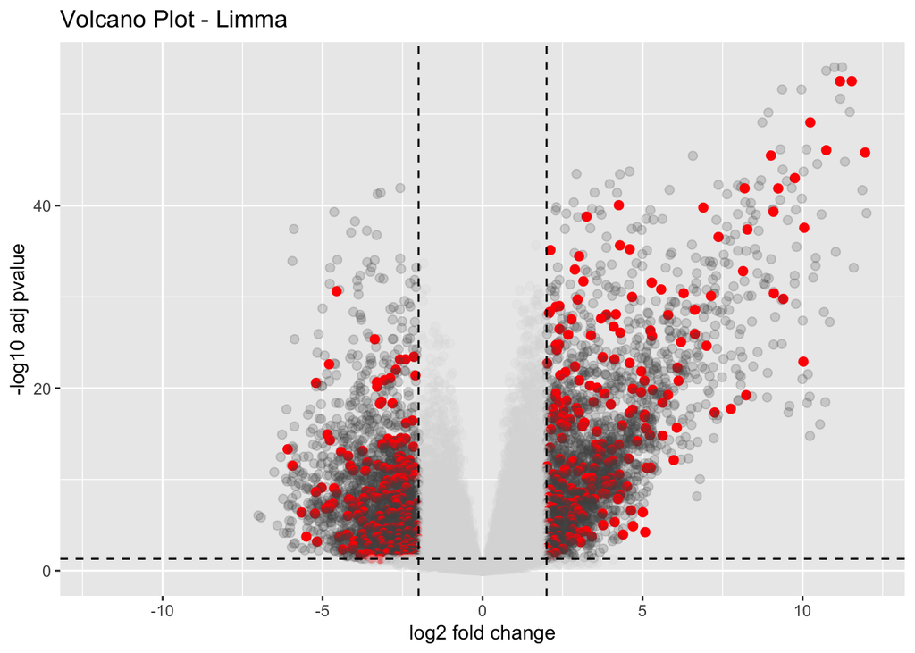

```r
#set the contrast names for when we plot the results
contrast.names <- c("E","M","L")

# get all metabolic genes
metabolic.genes <- c(metabolic.signatures$allGenesTested)

# do volcano plots for each lineage, overlaying the expression of all metabolic genes
res.E <- topTable(fit.cont, coef=1, number=nrow(v$E), adjust.method="BH")
res.E <- res.E[order(res.E$adj.P.Val),]
nsign.E <- length(which(res.E$adj.P.Val < 0.05))
nsignfc.E <- length(which(res.E$adj.P.Val < 0.05 & abs(res.E$logFC) > 1))
LimmaVolcano(res.E)
```

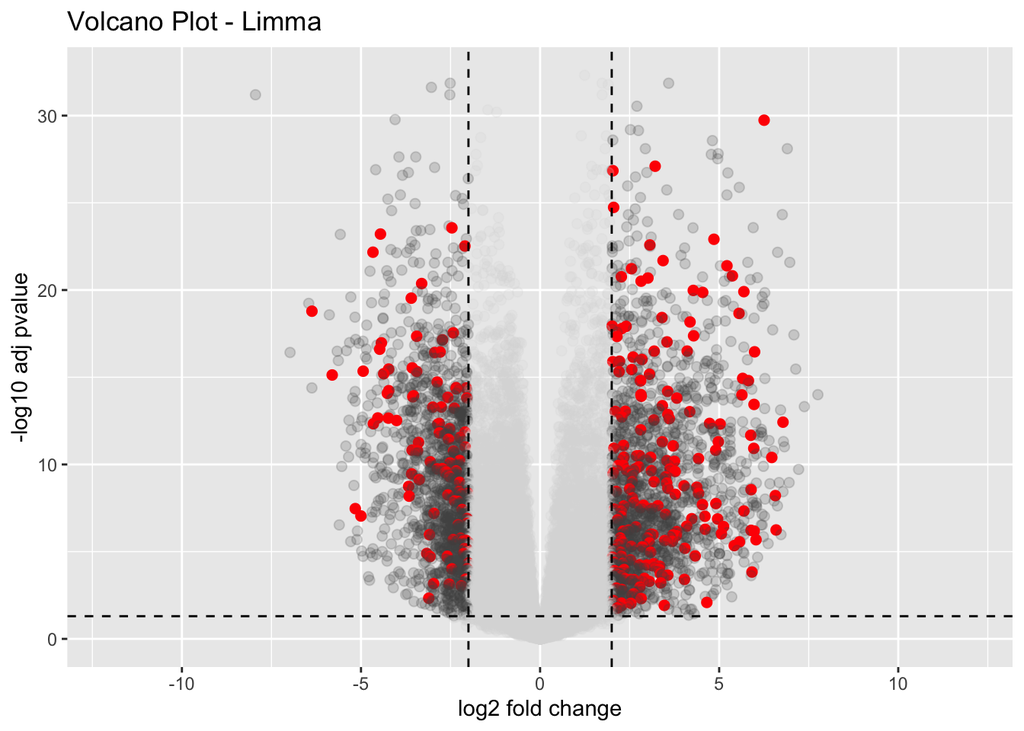

```r
res.E.filtered <- res.E[res.E$adj.P.Val < 0.05,]

res.M <- topTable(fit.cont, coef=2, number=nrow(v$E), adjust.method="BH")
res.M <- res.M[order(res.M$adj.P.Val),]
nsign.M <- length(which(res.M$adj.P.Val < 0.05))
nsignfc.M <- length(which(res.M$adj.P.Val < 0.05 & abs(res.M$logFC) > 1))
LimmaVolcano(res.M)
```

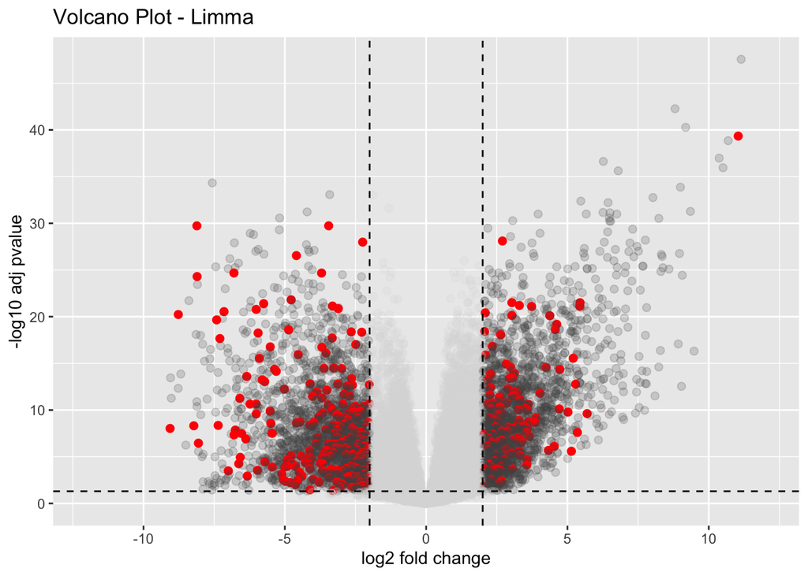

```r
res.M.filtered <- res.M[res.M$adj.P.Val < 0.05,]

res.L <- topTable(fit.cont, coef=3, number=nrow(v$E), adjust.method="BH")
res.L <- res.L[order(res.L$adj.P.Val),]
nsign.L <- length(which(res.L$adj.P.Val < 0.05))
nsignfc.L <- length(which(res.L$adj.P.Val < 0.05 & abs(res.L$logFC) > 1))
LimmaVolcano(res.L)
```

```r
res.L.filtered <- res.L[res.L$adj.P.Val < 0.05,]

write.csv(res.L.filtered, "Results/Module1/DEGs_L.csv")
write.csv(res.E.filtered, "Results/Module1/DEGs_E.csv")
write.csv(res.M.filtered, "Results/Module1/DEGs_M.csv")
```

# 6 Gene-set overrepresentation analysis

Approach 1. Geneset overrepresentation analysis: This works by seeing if your differentially expressed genes occur at a high frequency in a given geneset, relative to chance. The Null hypothesis here is that if a geneset represents 1% of all genes in the experiment then 1% of the genes in the pathway would be differentially expressed. This does assume that genes are independent which has been shown not to be true. We perform these analyses using the kegga and goana methods available in the limma package.

```r
for(i in 1:length(contrast.names)){

  go <- goana(fit.cont, coef=i,species = "Mm",geneid = haemopedia$entrezgene[rownames(haemopedia$counts) %in% rownames(v$E)])
  kegg <- kegga(fit.cont, coef=i,species = "Mm",geneid = haemopedia$entrezgene[rownames(haemopedia$counts) %in% rownames(v$E)])

  go$FDR.up <- p.adjust(go$P.Up, method = "BH", n = length(go$P.Up))
  go$FDR.down <- p.adjust(go$P.Down, method = "BH", n = length(go$P.Down))

  kegg$FDR.up <-  p.adjust(kegg$P.Up, method = "BH", n = length(kegg$P.Up))
  kegg$FDR.down <- p.adjust(kegg$P.Down, method = "BH", n = length(kegg$P.Down))

  kegg <- kegg[kegg$FDR.up < 0.1 | kegg$FDR.down < 0.1,]
  go <- go[go$FDR.up < 0.1 | go$FDR.down < 0.1,]
  write.csv(go,   paste( "Results/Module1/" ,contrast.names[i],"GOANA_GO_pathways.csv",sep="_"))
  write.csv(kegg, paste( "Results/Module1/" ,contrast.names[i],"KEGGA_KEGG_pathways.csv",sep="_"))
}
```

```r
#get the indices of the dataset that correspond to each geneset
load("genesets/geneset_Robjects/KEGG.Rda")
KEGG.ind <- ids2indices(KEGG.sets, rownames(v))

for(i in 1:length(contrast.names)){

  print(contrast.names[i])

  KEGG.camera <- camera(v,index = KEGG.ind,design=design,contrast = cont.matrix[,i],inter.gene.cor=0.01)
  KEGG.fry <- mroast(v, index = KEGG.ind, design = design, contrast = cont.matrix[,i], sort = "mixed",set.statistic = "mean50")

  KEGG.camera <- KEGG.camera[KEGG.camera$FDR < 0.1,]
  KEGG.fry <- KEGG.fry[KEGG.fry$FDR < 0.1,]

  write.csv(KEGG.camera, paste( "Results/Module1/" , contrast.names[i],"CAMERA_KEGG_pathways.csv",sep="_"))
  write.csv(KEGG.fry, paste( "Results/Module1/"  , contrast.names[i],"FRY_KEGG_pathways.csv",sep="_"))
}
```

# 7 References:

1. Choi, J. et al. “Haemopedia RNA-Seq: A Database of Gene Expression during Haematopoiesis in Mice and Humans.” Nucleic Acids Research 47, no. D1 (January 8, 2019): D780–85. https://doi.org/10.1093/nar/gky1020.
2. Ritchie, Matthew E. et al. “Limma Powers Differential Expression Analyses for RNA-Sequencing and Microarray Studies.” Nucleic Acids Research 43, no. 7 (April 20, 2015): e47–e47. https://doi.org/10.1093/nar/gkv007.
3. Butler, Andrew et al. Integrating Single-Cell Transcriptomic Data across Different Conditions, Technologies, and Species. Nature Biotechnology 36, no. 5 (May 2018). https://doi.org/10.1038/nbt.4096.
4. Calvo, Sarah E., Karl R. Clauser, and Vamsi K. Mootha. “MitoCarta2.0: An Updated Inventory of Mammalian Mitochondrial Proteins.” Nucleic Acids Research 44, no. D1 (January 4, 2016): D1251–57. https://doi.org/10.1093/nar/gkv1003.
5. Wu, Di, and Gordon K. Smyth. “Camera: A Competitive Gene Set Test Accounting for Inter-Gene Correlation.” Nucleic Acids Research 40, no. 17 (September 1, 2012): e133–e133. https://doi.org/10.1093/nar/gks461.
6. Wu, Di, et al. “ROAST: Rotation Gene Set Tests for Complex Microarray Experiments.” Bioinformatics 26, no. 17 (September 1, 2010): 2176–82. https://doi.org/10.1093/bioinformatics/btq401.